# Global Inequality

Dr. Fatima Alqabandi · Kuwait University

Chapter 9 · Based on Richard T. Schaefer, *Sociology: A Brief Introduction*, 14th ed.

# The United Nations on Global Poverty

Global poverty rates have fallen by more than half since 2000, yet about one person in ten still lives in extreme poverty. This chapter asks why some nations are rich and others poor, and how inequality plays out inside each nation.

## Predict: Could You Live on $1.90 a Day?

The international poverty line is **US$1.90 a day** per person. That has to cover food, water, transport, and rent or housing. What could you buy with it in Kuwait today?

- $1.90 is about **580 fils** a day, or about **17.5 dinars** for a whole month
- One in ten people in developing regions lives below this line, and millions of others live on slightly more (United Nations 2018)

## The UN’s Poverty Facts and Figures

[figure not shown]

- About **10 percent** of the world’s population lives in **extreme poverty**, struggling to meet basic needs such as food, clean water, and access to education
- Most of them live in two regions: **southern Asia** and **sub-Saharan Africa**. In sub-Saharan Africa, up to **42 percent** of the population lives below the line
- Poverty affects men and women unequally: for every **100 men** aged 25 to 34 who live in poverty, there are **122 women**

Poverty means more than a lack of income. It means hunger, malnutrition, lack of education, lack of basic government services, discrimination, exclusion from opportunities, and lack of agency.

# The Global Divide

A few centuries ago, almost everyone in the world was poor. Today the gap is so wide that the poorest people in a rich country live like the typical person in a poor one.

## Coping Mechanisms: How the Desperately Poor Control Their Hunger

- People who have dedicated their lives to fighting starvation speak of **“coping mechanisms”**: ways in which the desperately poor try to control their hunger
- **Eritrean** women strap flat stones to their stomachs to lessen their hunger pangs
- In **Mozambique**, people eat the grasshoppers that destroyed their crops, calling them “flying shrimp”
- Among the well-fed, eating dirt is a pathological condition called **pica**. The world’s poor eat dirt to add minerals to their diet
- In many countries, mothers boil stones in water to convince their hungry children that supper is almost ready, hoping the children will fall asleep (McNeil 2004)

[figure not shown]

Women carry their village’s food aid from a World Food Programme distribution point in Epworth, Harare, Zimbabwe, April 2009. Kate Holt/AusAID, CC BY 2.0, Wikimedia Commons.

Inequality is a significant determinant of human behavior. It opens doors of opportunity to some and closes them to others.

## The Industrial Revolution Opened the Global Divide

- A few centuries ago, such vast divides in global wealth **did not exist**. Except for a very few rulers and landowners, everyone in the world was poor. Life in much of Europe was as difficult as it was in Asia or South America
- The **Industrial Revolution** and rising agricultural productivity produced explosive economic growth. The rise in living standards was **not evenly distributed** across the world

[figure not shown]

Power-loom weaving in an English cotton mill, 1835. Engraving by J. Tingle after T. Allom, public domain, [Wikimedia Commons](https://commons.wikimedia.org/wiki/File:Powerloom_weaving_in_1835.jpg).

- Researchers compared four measures: life expectancy, the chance that a baby survives its first year, and the rates of homicide and incarceration. In every case, the **poorest of the poor in the United States** matched the experience of people in the **poorest countries**
- The typical person in a low-income country lives like the poorest of the poor in the United States (Shaefer et al. 2018)

## Predict: Where Do the Terms “First World” and “Third World” Come From?

People joke online about “First World problems”: a cracked phone screen, the wrong coffee order. Where did the labels First, Second, and Third World come from?

- They date from the **Cold War**. Western policymakers called Western capitalist countries the **First World**, the Soviet Union and its allies the **Second World**, and everyone else, the nonaligned countries, the **Third World**
- After the Cold War, the Second World disappeared, but “First” and “Third” stuck and came to mean rich and poor
- The labels are outdated and inaccurate. “Third World” lumped together more than 100 very different countries: average income per person in **Botswana** is about **nine times** that of **Rwanda**
- Sociologists now group countries by their **economic productivity**

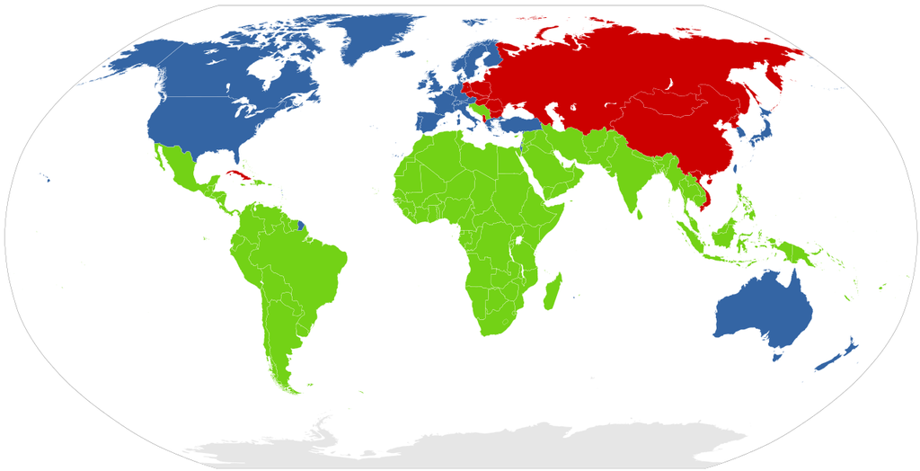

The First (blue), Second (red), and Third (green) Worlds during the Cold War.

# Stratification in the World System

Sociologists see a continuum of nations, from the richest to the poorest. Three forces keep a few nations on top: the legacy of colonialism, multinational corporations, and modernization.

## A Continuum of Nations: Gross National Income per Person

- The divide between industrialized and developing nations is sharp, but sociologists recognize a **continuum** of nations, from the richest of the rich to the poorest of the poor
- **Per capita gross national income** is the average value of goods and services produced per citizen

In 2019, per capita gross national income in the United States, the Netherlands, Switzerland, Ireland, and Norway was more than **$62,000**. In at least 23 poorer countries it was **$2,000 or less**. How many times larger is the first figure?

- **More than 31 times.** Most countries fall somewhere between those extremes (Figure 9-1; World Bank 2019c)

## Colonialism Defined: Rule by Outsiders

- **Colonialism** — occurs when a foreign power maintains **political, social, economic, and cultural domination** over a people for an extended period. In simple terms, it is **rule by outsiders**
- The British Empire ruled much of North America, parts of Africa, and India. France ruled Algeria, Tunisia, and other parts of North Africa
- The relationship between a colonial nation and a colonized people resembles the one Marx described between the **capitalist class** and the **proletariat** (Chapter 8)
- By the **1980s**, colonialism had largely disappeared. Most nations that were colonies before World War I had achieved political independence and established their own governments

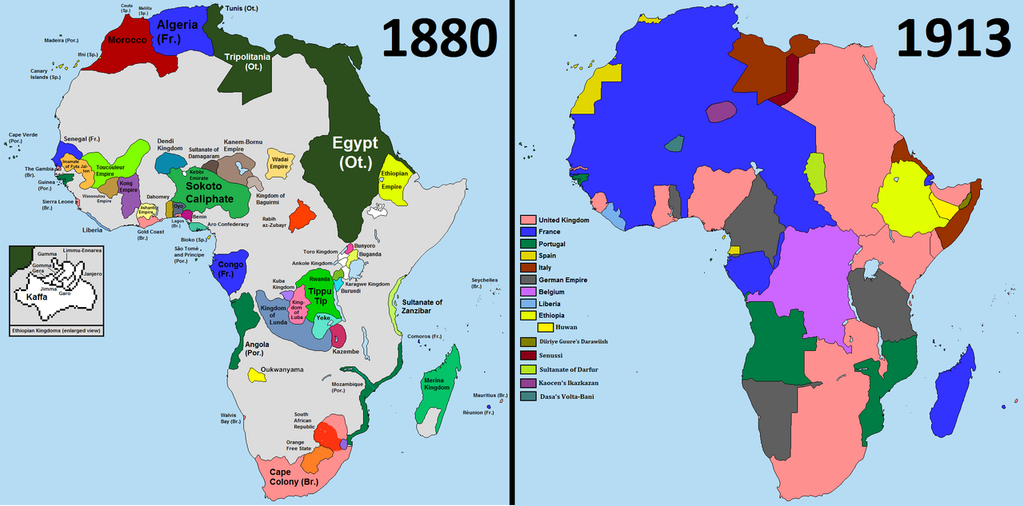

Africa in 1880 and 1913, before and after the European “Scramble for Africa.”

## Neocolonialism: Dependence Continued After Independence

[figure not shown]

- For many former colonies, the transition to genuine self-rule was **not complete**. Colonial domination had set up patterns of economic exploitation that continued after independence, partly because former colonies could not develop their own **industry and technology**
- **Neocolonialism** — continuing dependence on and foreign domination by more industrialized nations, including former colonial masters

## Wallerstein’s World Systems Analysis

- Drawing on the **conflict perspective**, sociologist **Immanuel Wallerstein** saw the global economic system as divided between nations that **control wealth** and nations from which **resources are taken**
- **World systems analysis** — an interdependent global economy resting on **unequal economic and political relationships**
- Nations by themselves have never been whole systems. They exist within a larger, **global** social context
- **Core:** industrialized nations, among them the United States, Japan, and Germany, and their global corporations. Unlike other nations, they are relatively **independent of outside control**
- **Semiperiphery:** countries with marginal economic status, such as Ireland and South Korea
- **Periphery:** the poor developing countries of Asia, Africa, and Latin America
- The key is the **exploitative relationship** of core nations toward noncore nations. Core nations and their corporations control and exploit noncore nations’ economies (Chase-Dunn and Grimes 1995; G. Williams 2013)

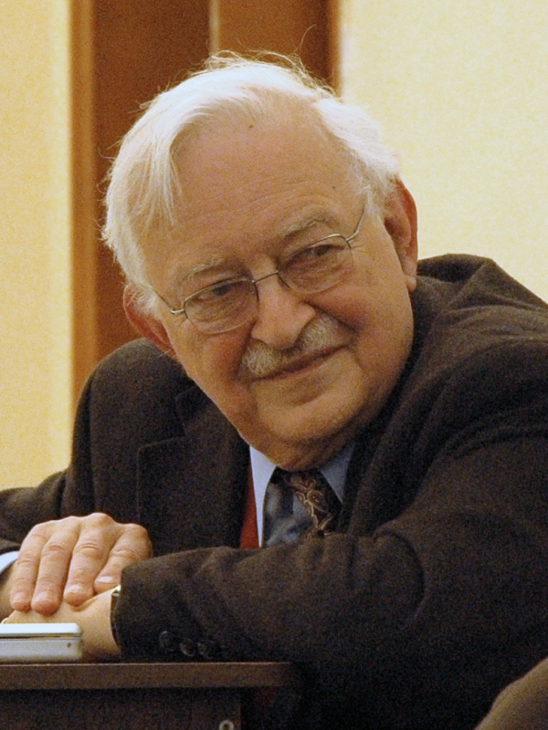

Immanuel Wallerstein (1930–2019) in St. Petersburg, 2008. Alexei Kouprianov, CC BY-SA 3.0, [Wikimedia Commons](https://commons.wikimedia.org/wiki/File:Immanuel_Wallerstein.2008.jpg).

## Figure 9-2: World Systems Analysis

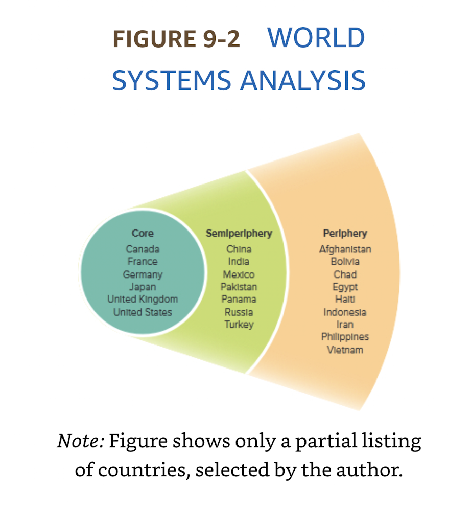

## The Core–Periphery Division Is Remarkably Stable

- A study by the **International Monetary Fund** (2000; Alvaredo 2011) found **little change over 125 years** among more than 24 economies
- The only changes: **Japan** moved up into the core, and **China** moved down toward the margins of the semiperiphery

## Puzzle: Where Does Kuwait Fit in Wallerstein’s World System?

Kuwait does not appear in Figure 9-2. Weigh the evidence: core, semiperiphery, or periphery?

### Looks like the core

- High income per person: the World Bank classifies Kuwait as high income
- Invests abroad through the Kuwait Investment Authority, one of the oldest sovereign wealth funds in the world, with roots in 1953

### Looks like the periphery

- Exports mainly one raw material: crude oil
- Imports most manufactured goods, from cars and phones to medical equipment, along with much technical expertise

Schaefer places Ireland, with income above $62,000 per person, in the **semiperiphery**. If Wallerstein’s categories do not follow income, what do they follow?

World systems analysis ranks nations by their place in relationships of **control and dependence**, not by income alone.

## Dependency Theory: Developing Nations Remain Subservient

- Wallerstein’s world systems analysis is the most widely used version of **dependency theory**
- **Dependency theory** — a macro-level theory: even as developing countries make economic advances, they remain **weak and subservient** to core nations and corporations in an increasingly intertwined global economy
- This interdependency allows industrialized nations to keep exploiting developing countries. Dependency theory applies the **conflict perspective on a global scale**
- In this view, a growing share of developing countries’ **human and natural resources** is redistributed to the core industrialized nations

## Dependency Theory: How Debt Deepens Dependence

[figure not shown]

- The **global debt crisis** has intensified the Third World dependency that began under colonialism, neocolonialism, and multinational investment. International financial institutions press indebted countries to take severe measures to meet their **interest payments**

## Globalization Defined: The Role of the World Bank and the IMF

- **Globalization** — the worldwide integration of government policies, cultures, social movements, and financial markets through **trade and the exchange of ideas**
- World financial markets reach beyond the control of any one nation-state. So international organizations such as the **World Bank** and the **International Monetary Fund** have become major players in the global economy
- Their function is to encourage trade and development and to keep international financial markets running smoothly. Because **core nations** fund and influence them heavily, critics see them as promoters of globalization and defenders mainly of core nations’ interests
- Some observers see globalization as the natural result of advances in **communications technology**, especially the Internet and worldwide mass media. Others see it as a process that lets **multinational corporations** expand unchecked (Chase-Dunn et al. 2000; Guenther and Kasi 2015)

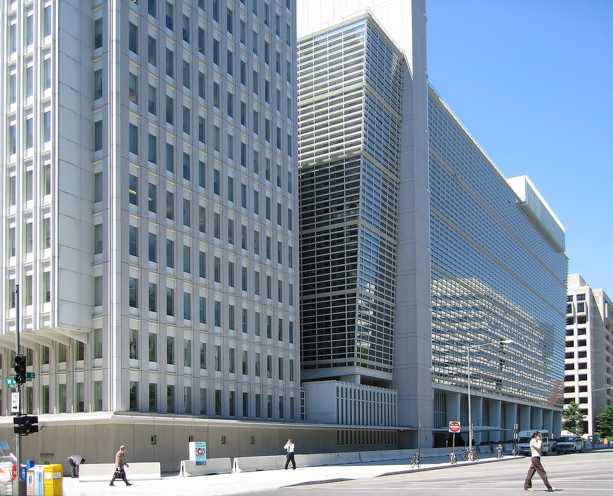

World Bank headquarters, Washington, D.C., 2004. Shiny Things, CC BY 2.0, [Wikimedia Commons](https://commons.wikimedia.org/wiki/File:World_Bank_building_at_Washington.jpg).

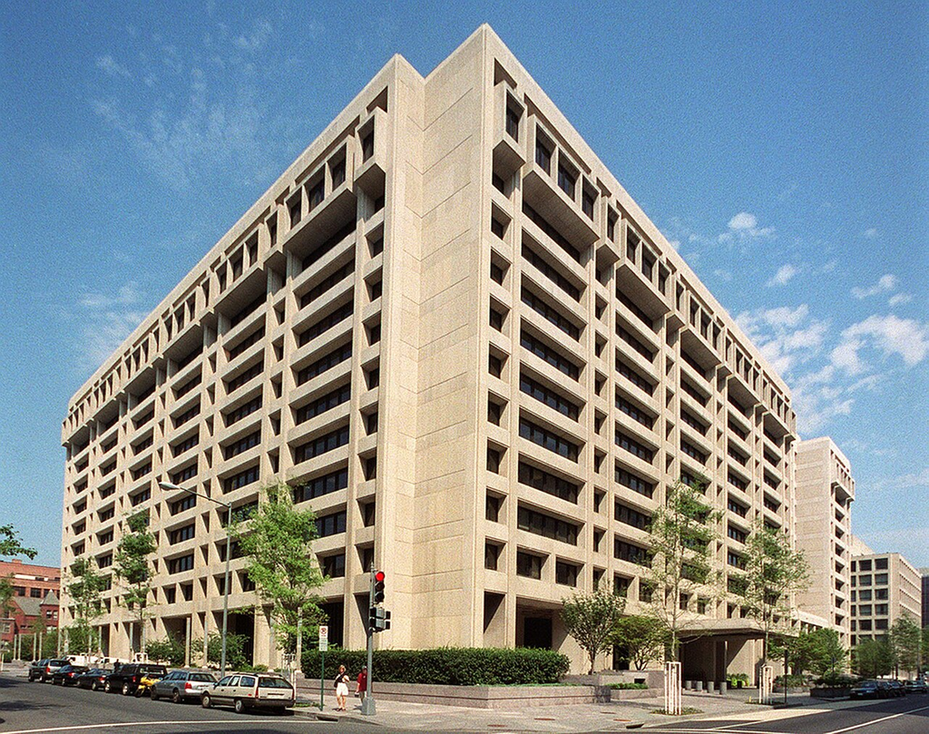

IMF headquarters, Washington, D.C. International Monetary Fund, public domain, [Wikimedia Commons](https://commons.wikimedia.org/wiki/File:IMF_building_HR.jpg).

## Critics of Globalization: Workers, the Environment, and Cultural Identity

- Critics point to **violations of workers’ rights**, **destruction of the environment**, **loss of cultural identity**, and **discrimination against minority groups** in periphery nations
- Globalization appears most problematic for developing countries in **Latin America and Africa**
- Developing nations in **Asia** seem to do better: foreign investment there involves the **high-tech sector**, which produces more sustainable growth
- Even in Asia, globalization has **not reduced income disparities**, between nations or within them (Kerbo 2006)

# Poverty Worldwide

In 2000 the United Nations set out to halve extreme poverty. The world came close, but mostly through growth in a few emerging economies rather than through foreign aid.

## Foreign Aid: Total Dollars or Share of National Income?

Which country is more generous: the one that gives the most dollars, or the one that gives the largest share of its national income?

- When the UN launched the **Millennium Project** in **2000** to halve extreme poverty by 2015, only **five** countries gave foreign aid at the target rate: **Denmark, Luxembourg, Great Britain, Norway, and Sweden**
- In dollar terms, the **U.S. government** gives far more aid than any other nation. As a **percentage of gross national income**, its contribution is among the **lowest** of the 23 most advanced industrialized countries, on a par with **South Korea’s**
- The **pandemic** led developed nations to refocus on economic and social needs at home

## Predict: How Far Did Extreme Poverty Fall Between 1990 and 2015?

In 1990, **1.9 billion** people lived on less than $1.25 a day. How many did in 2015? Which single country accounted for almost half of the decline?

[figure not shown]

# Multinational Corporations

Some companies now earn as much as entire nations produce. Functionalists say they bring jobs and new technology; conflict theorists say they exploit workers and deepen inequality.

## Multinational Corporations Defined: Global Factories and the Global Office

- **Multinational corporations** — commercial organizations that are **headquartered in one country** but do business **throughout the world**
- **Global factories** — factories throughout the developing world run by multinational corporations
- The **global office** may soon sit alongside them. Multinationals based in core countries are setting up reservation services and centers for processing data and insurance claims in **periphery nations**, because low overseas costs more than offset the cost of sending information around the world
- Worldwide, corporate giants play a key role in **neocolonialism**

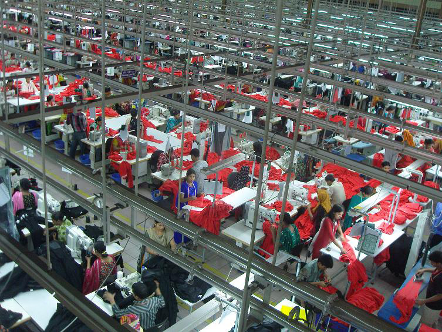

A global factory: a garment factory in Bangladesh, 2012. Fahad Faisal, CC BY-SA 3.0, [Wikimedia Commons](https://commons.wikimedia.org/wiki/File:Garments_Factory_in_Bangladesh.JPG).

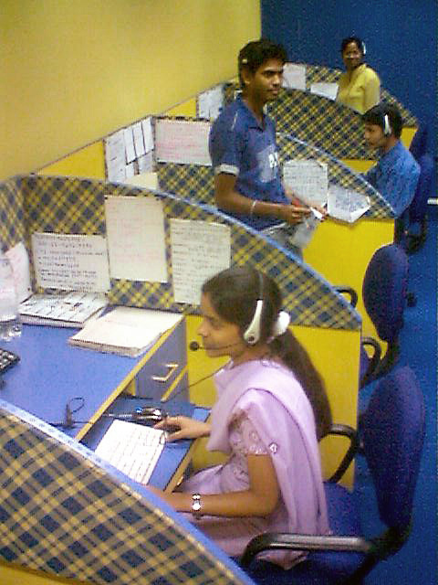

A global office: a call center in India, 2006. Sonamsaxena, public domain, [Wikimedia Commons](https://commons.wikimedia.org/wiki/File:An_Indian_call_center.jpg).

## Predict: Which Companies Earn as Much as Entire Nations?

Match each company’s yearly revenue to the country with a similar gross domestic product.

### Companies

1. Royal Dutch Shell (Britain and the Netherlands)
2. Saudi Aramco (Saudi Arabia)
3. Toyota (Japan)
4. Amazon (United States)
5. CVS Health (United States)

### Countries

- Qatar
- Bangladesh
- Nigeria
- Romania
- Malaysia

## Figure 9-4: Multinational Corporations Compared to Nations

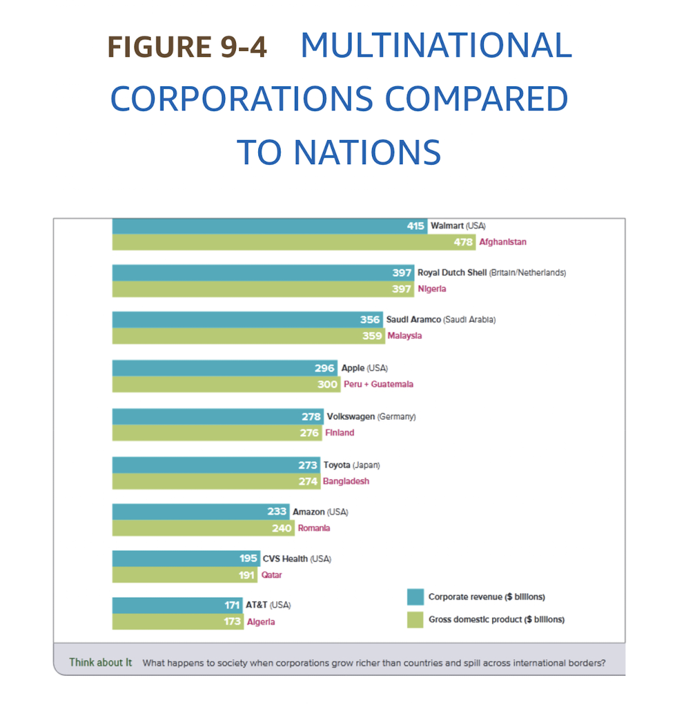

- Do not underestimate their size: the revenues of multinationals are **on a par with** the total value of goods and services in entire nations
- Foreign sales are an important source of profit, so multinationals constantly seek to expand into other countries, often **developing nations**

What happens to society when corporations grow richer than countries and spill across international borders?

Corporate revenue for 2019; GDP for 2018 (World Bank 2020a). The Afghanistan value appears to be a misprint: World Bank data put Afghanistan’s 2018 GDP near $18 billion.

## Functionalist View: Multinationals Can Help Developing Nations

- Multinationals bring **jobs and industry** to areas where **subsistence agriculture** was once the only means of survival
- They promote rapid development through the **diffusion of inventions and innovations** from industrialized nations
- The combination of skilled technology and management from multinationals with the relatively **cheap labor** of developing nations is ideal for a global enterprise. Multinationals use technology fully while reducing costs and boosting profits
- Their international ties make nations more **interdependent**, which may keep disputes from becoming serious conflict. A country cannot afford to cut diplomatic relations or go to war with the nation that is home to its main suppliers or a key market for its exports

## Conflict View: Multinationals Exploit Workers to Maximize Profits

- Conflict theorists stress that multinationals **exploit local workers** to maximize profits. The pool of cheap labor in the developing world prompts them to move factories **out of core countries**
- The developing world also discourages **strong trade unions**. Governments seeking to attract or keep multinationals may create a **“climate for investment”** that includes repressive antilabor laws restricting union activity and collective bargaining
- If labor’s demands become too threatening, the firm simply **moves its plant**, leaving unemployment behind. **Nike** moved its factories from the United States to **Korea** to **Indonesia** to **Vietnam** in search of the lowest labor costs
- Conflict theorists conclude that, on the whole, multinationals have a **negative social impact on workers** in both industrialized and developing nations

## Foreign Investment Increases Inequality Within Developing Nations

- Several sociologists who surveyed the effects of foreign investment conclude that it may at first add to a host nation’s wealth, but **eventually increases economic inequality** within developing nations, in both **income** and **land ownership**
- The **upper and middle classes** benefit most from economic expansion; the **lower classes** benefit least
- Multinationals invest in **limited economic sectors** and **restricted regions** of a nation. Sectors such as hotels and expensive restaurants expand, and their expansion appears to slow growth in **agriculture** and other sectors
- Multinationals often **buy out or force out local entrepreneurs** and companies, increasing economic and cultural dependence (Chase-Dunn and Grimes 1995; Kerbo 2012; Wallerstein 1979b)

## Functionalist or Conflict? Classify the Claim About Multinationals

Which perspective would make each claim?

1. “The new factory gave our village its first paid jobs.”
2. “The company left for a cheaper country as soon as workers asked for a raise.”
3. “Engineers trained by the foreign firm later started their own companies.”
4. “Two countries that trade this much will think twice before going to war.”
5. “The new beach hotels are booming, but farm incomes have not moved.”
6. “The government banned strikes to keep the investors happy.”

## Functionalist and Conflict Views of Multinational Corporations Compared

[figure not shown]

# Modernization

Modernization theory says poor nations will develop by following the rich. Its critics ask who decides what counts as “modern” in the first place.

## Modernization Defined: Wendell Bell’s Traits of Modern Societies

- Globalization and multinational corporations have changed developing countries **culturally**, not only economically
- **Modernization** — the far-reaching process through which **periphery nations** move from traditional or less developed institutions to those characteristic of more developed societies
- Sociologist **Wendell Bell** (1981), whose definition Schaefer uses, notes that modern societies tend to be **urban, literate, and industrial**. Members must shift their allegiance from traditional authorities to newer ones

[figure not shown]

## Is “Modernization” an Ethnocentric Term?

- Many sociologists note that terms such as *modernization* and even *development* carry an **ethnocentric bias** (Chapter 3)
- The unstated assumption: “they,” people in developing nations, are struggling to become more like **“us,”** people in core industrialized nations
- From a **conflict perspective**, these terms perpetuate the **dominant ideology** of capitalist societies (Chapter 8)
- *Modernization* also suggests **positive change**. Yet change, if it comes, often comes slowly, and it tends to serve the **affluent segments** of industrialized nations. The spread of the latest electronic technologies to the developing world follows this pattern

Who decides what counts as “modern”?

## Modernization Theory and Its Critics

- **Modernization theory** — a **functionalist** approach that proposes that modernization and development will gradually **improve the lives** of people in developing nations
- Nations develop at uneven rates, but the development of peripheral nations will be assisted by **innovations transferred** from the industrialized world
- Critics, including **dependency theorists**, counter that such technology transfer only **increases the dominance** of core nations and facilitates further exploitation
- Current modernization studies take a **convergence perspective**: using social indicators, researchers study how societies are **moving closer together**, despite traditional differences

## Social Indicators of Modernization and the Persistence of Tradition

- When Coca-Cola and Apple signs go up in developing nations, it is easy to assume that economic change brings cultural change. Researchers note that it **does not always**
- Distinctive cultural traditions, such as a particular **religious orientation** or a **nationalistic identity**, often **persist** and can soften the impact of modernization
- Some contemporary sociologists stress that **both** industrialized and developing countries are “modern”
- Researchers increasingly gauge modernization with **social indicators**: degree of **urbanization, energy use, literacy, political democracy, and use of birth control**
- Some indicators are **subjective**. Even in industrialized nations, not everyone would agree that wider use of birth control is an example of progress (Armer and Katsillis 1992; Hedley 1992; Inglehart and Baker 2000)

[figure not shown]

A Coca-Cola sign in Parys, South Africa, 2009. Ossewa, CC BY 4.0, [Wikimedia Commons](https://commons.wikimedia.org/wiki/File:Coca-Cola_sign_in_Parys.jpg).

## Table 9-1: Sociological Perspectives on Global Inequality

| Approach | Sociological perspective | Explanation |
| --- | --- | --- |
| **World systems analysis** | Functionalist and conflict | Unequal economic and political relationships maintain sharp divisions between nations |
| **Dependency theory** | Conflict | Industrialized nations exploit developing nations through colonialism and multinational corporations |
| **Modernization theory** | Functionalist | Developing nations move away from traditional cultures and toward the cultures of industrialized nations |

Schaefer’s text says Wallerstein drew on the conflict perspective; Table 9-1 lists world systems analysis under both perspectives.

# Stratification Within Nations

The gap between rich and poor is widening between nations and within them. Every nation in Schaefer’s comparison shows significant income inequality.

## Local Elites, Multinationals, and Inequality Inside Developing Nations

- As the gap between rich and poor **nations** widens, so does the gap between rich and poor **citizens within nations**
- Stratification in developing nations is closely tied to their **weak and dependent position** in the global economy
- **Local elites** work hand in hand with multinational corporations and prosper from these alliances. The economic system creates and perpetuates the exploitation of **industrial and agricultural workers**
- Schaefer’s chapter opens with a photo of **Paraisópolis**, a shantytown in São Paulo, Brazil, with high-rise apartment buildings right behind it

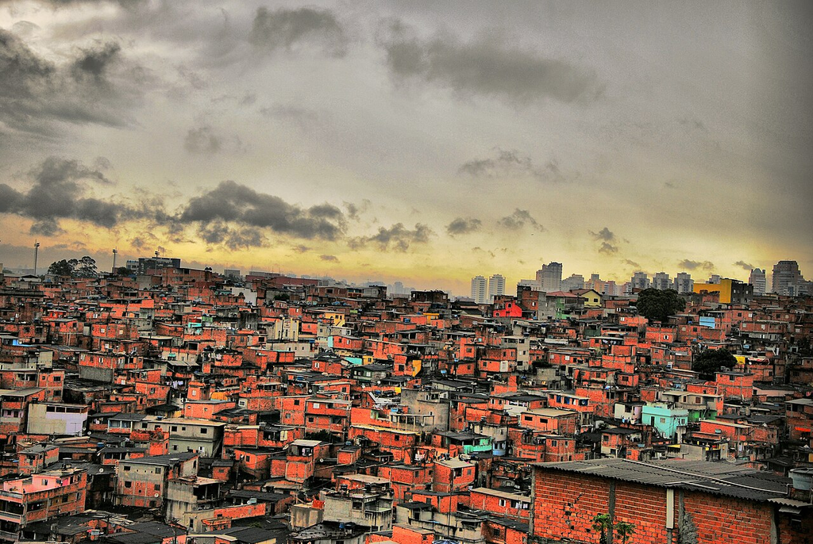

Paraisópolis, São Paulo, with apartment towers on the horizon, 2014. Roberto Rocco (TU Delft), CC BY-SA 4.0, [Wikimedia Commons](https://commons.wikimedia.org/wiki/File:Favela_Paraisopolis_Sao_Paulo_2014_A.jpg).

## Predict: How Many Billionaires Equal Half the World?

How many of the world’s wealthiest individuals would it take to match the combined wealth of the **poorer half of the world’s population**?

- **26.** The world’s 26 wealthiest individuals have accumulated wealth equal to that of **more than half** of the world’s population
- Just as a few corporations have amassed great sums of money, so have a very few individuals
- The inequality across the world is replicated **within countries**

## Predict: Which Nation Has the Widest Income Gap?

Figure 9-5 compares the share of income received by the richest fifth and the poorest fifth of the population in nine nations: Brazil, the Czech Republic, Great Britain, Hungary, Ireland, Mexico, Russia, Sweden, and the United States. Which has the widest gap? Which has the narrowest?

[figure not shown]

# Social Mobility in Global Perspective

In rich nations, sociologists track people moving between occupations. In developing nations, the mobility that matters most is the move out of poverty.

## Mobility in Industrial Nations: Three Patterns

- Studies of **intergenerational mobility** in industrialized nations find:
  1. **Substantial similarities** in the ways parents’ positions in the stratification system are passed to their children
  2. Mobility is influenced by **structural factors**, such as labor market changes that raise or lower an occupational group in the social hierarchy
  3. **Immigration** continues to shape a society’s level of intergenerational mobility
- Cross-cultural studies suggest that intergenerational mobility has **increased** over the past 50 years in most but not all countries, with a common movement **away from agriculture-based occupations**
- Growth in mobility does **not** necessarily bring growth in equality. The gap between rich and poor has **grown**, and poverty levels in the 30 largest industrial economies have stayed relatively constant for 30 years (Eurostat 2015; OECD 2008)

## Mobility in Developing Nations: From Village to City, and Out of Poverty

- In developing nations, **macro-level** social and economic changes often overshadow **micro-level** movement from one occupation to another
- A large **wage gap between rural and urban areas** leads to high levels of migration to the cities. Yet urban industrial sectors generally cannot provide enough jobs for everyone seeking work
- In large developing nations, the most socially significant mobility is the **movement out of poverty**. It is hard to measure, because economic trends differ from one area of a country to another
- **Downward mobility** is dramatically influenced by catastrophes such as **crop failure and warfare**
- Not all is bleak. At the start of the 21st century, millions entered the **middle class** in China, India, Russia, Brazil, and Mexico, through **entrepreneurship, microfinancing, merchandising**, and in some countries a growing, relatively **well-paid government sector** (Beddoes 2012)

[figure not shown]

Shenzhen North station during Chunyun, the Lunar New Year travel rush, when millions of migrant workers return to their home villages, 2016. Baycrest, CC BY-SA 2.5, [Wikimedia Commons](https://commons.wikimedia.org/wiki/File:Shenzhen_North_Railway_Station_Concourse_2016_Chunyun.jpg).

Schaefer lists a well-paid government sector as one route into the middle class. Where have you seen that route at work?

## Predict: Will Children Grow Up to Be Better Off Than Their Parents?

Quick vote: do you expect to be financially better off than your parents? Then predict: in a 27-nation survey, which countries were most optimistic about their children’s future: France, Japan, the United States, Mexico, Brazil, Russia, India, or the Philippines?

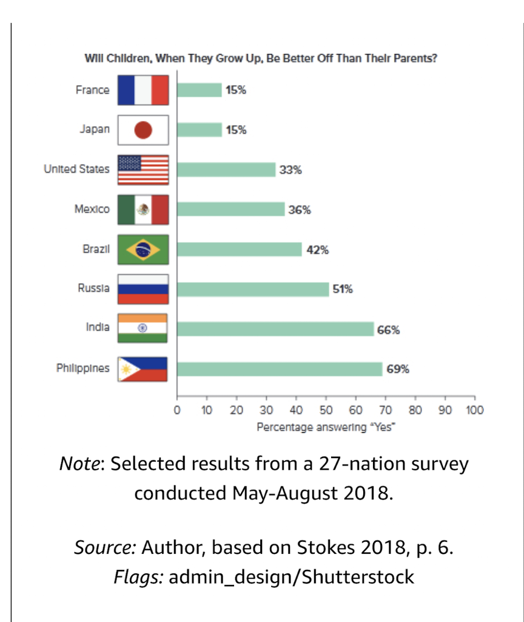

## Box 9-3: Getting Ahead Globally

- In surveys across **27 nations**, a majority in every country believes that **a good education and hard work** are key to getting ahead. Majorities also agree that the **gap between rich and poor** is a problem
- Generally, the **poorer the country**, the more optimistic people are that their children will be better off. Adults in **industrial countries** are more cautious
- Yet many see more opportunity abroad: **23 percent** of Mexicans and **42 percent** of Senegalese recommend that young people move abroad for “a good life”
- Economic optimism seems greatest when the **parents’ own status is the most marginal**. So discussions of mobility must be framed within the context of a **particular society**

Schaefer asks: why are people in poor countries more optimistic about their children’s futures than people in rich ones? Recall Powell in Chapter 8: only about half of U.S. middle-class children now out-earn their parents.

## Gender Differences in Mobility in Developing Nations

- The challenges that women and girls face in developing countries are not limited to any one continent
- Anthropologist **Karuna Chanana Ahmed** calls women **the most exploited of oppressed people**. From birth, girls are commonly **fed less** than boys, **denied educational opportunities**, and often **hospitalized only when critically ill**
- Inside or outside the home, women’s work is **devalued**. When economies fail, as in Asian countries in the late 1990s, women are **the first to be laid off** (J. Anderson and Moore 1993; Kristof 1998)
- Surveys show a significant degree of **female infanticide**, the killing of baby girls, in China and rural India
- In **Pakistan**, only one-third of the sexually segregated schools are for girls, and one-third of those have no buildings

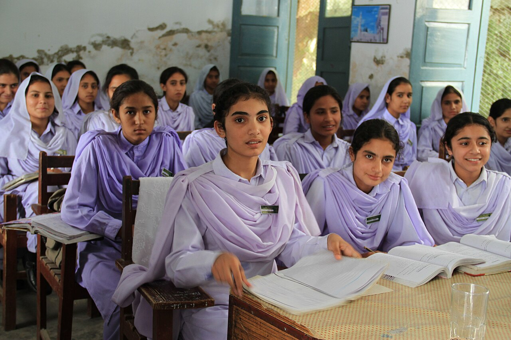

Girls in school in Khyber Pakhtunkhwa, Pakistan, 2011. UK Department for International Development, CC BY-SA 2.0, Wikimedia Commons.

## How Development Can Weaken Women’s Standing

- Only recently have researchers begun to study how **gender** shapes mobility in developing nations
- Modernization in rural areas and **rural-to-urban migration** may lead people to modify or abandon traditional cultural practices and even **marital systems**. The effects on women’s standing are **not necessarily positive**
- As a country develops, women’s vital role in **food production** deteriorates, jeopardizing their **autonomy and material well-being**
- Moving to the city weakens women’s ties to **relatives** who can provide food, financial help, and social support (Lawson 2008; United Nations Secretary General 2014)

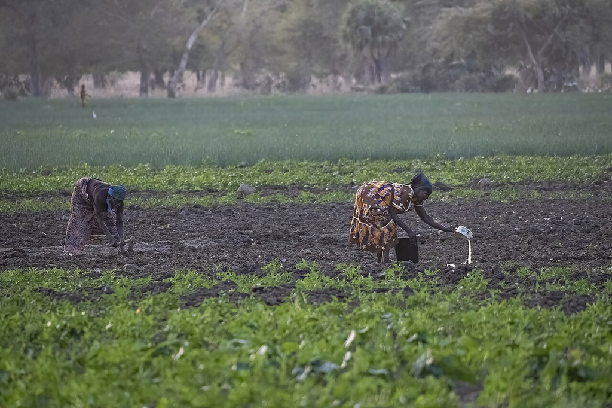

Women planting a field in Chad, 2025. MilanGIZ, CC BY-SA 4.0, [Wikimedia Commons](https://commons.wikimedia.org/wiki/File:2025_Chad_Women_working_on_agricultural_land.jpg).

Bell predicted that modern families become nuclear. What does a woman lose when her extended family no longer lives nearby? Who would care for her children while she works?

## The Pan-Cordillera Women’s Network in the Philippines

- In the **Philippines**, women have moved to the forefront of indigenous peoples’ struggle to protect their **ancestral land** from exploitation by outsiders
- Having won the right to the land’s minerals and forests, indigenous groups began to **feud among themselves** over how to develop them
- Aided by the United Nations Partners in Development Programme, women volunteers founded the **Pan-Cordillera Women’s Network for Peace and Development**
- The women mapped boundaries, prepared development plans, and negotiated **more than 2,000 peace pacts**. They also ran in elections, campaigned against social problems, and organized residents to work for the common good (United Nations Development Programme 2000)

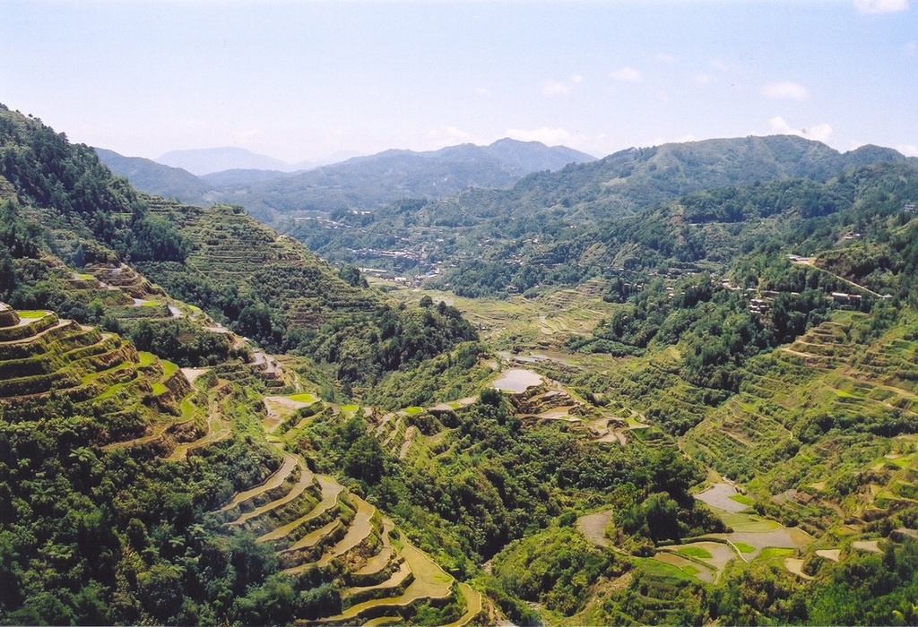

Rice terraces near Banaue in the Philippine Cordillera, 2003. Magalhães, public domain, [Wikimedia Commons](https://commons.wikimedia.org/wiki/File:Rice_Terraces_Banaue.jpg).

A worldwide view of stratification must include both the contrast between rich and poor nations and the layers of hierarchy, by class, gender, and other factors, within every nation.

## Before You Leave

- The **global divide** opened with the Industrial Revolution. The poorest people in the United States live like the typical person in a low-income country
- **Colonialism** is rule by outsiders; **neocolonialism** is continuing dependence after independence. **Wallerstein’s world systems analysis** divides nations into **core**, **semiperiphery**, and **periphery**, and the division has barely changed in 125 years
- **Dependency theory:** developing nations stay subservient, deepened by **debt**. **Globalization** integrates policies, cultures, and markets, promoted by the **World Bank** and the **IMF**
- The **Millennium Project** aimed to halve extreme poverty by 2015. Extreme poverty fell from **1.9 billion** to **836 million**, almost half of the decline in **China**. The pandemic pushed up to **60 million** back, and inequality **rose**
- **Multinational corporations:** functionalists see jobs, diffusion, and interdependence; conflict theorists see exploitation and rising inequality within host nations
- **Modernization** (Bell) carries an **ethnocentric bias**. **Modernization theory** is functionalist; current studies take a **convergence perspective** (Table 9-1)
- **Within nations:** every nation shows significant income inequality (Figure 9-5). In developing nations, the key mobility is **out of poverty**; poorer nations are more **optimistic**; **women** face the steepest barriers

Next: Chapter 12, The Family and Household Diversity.